# Data Exploration and Deterministic Functions

Sonja

19/9/2021

## Learning objectives

- Working with working directories
- Importing data from the internet and local files
- Data manipulation: merging data frames
- Graphical and numerical data exploration
- Installing R packages

In this assignment we work on use the habitat data set, ‘hab.sta.csv’, from a collection of the six relational data sets each of which describe different ecological information about “Oregon Birds”.

## Q1

### Histograms of each terrain variable

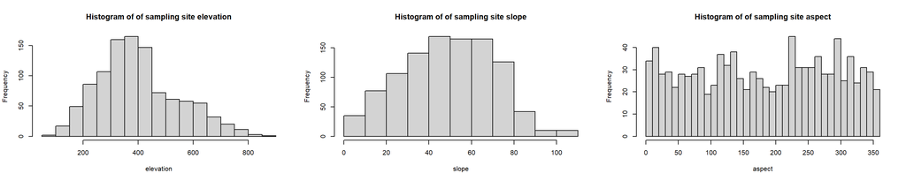

## Q2

The shape of the elevation histogram seems to be bell shaped with higher frequency of sampling sites to the center left of the plot (i.e. “right skew”). This indicates that there are more low to mid elevation sampling sights. It appears that the sampling distribution is biased towards sites at the 300-400 m range.

## Q3

The units of the slope are *percent slope (%)*

## Q4

The distributions of the slope data are also similarly bell shaped, like in the elevation data. The histogram plot shows that most of the slopes at the sampled sites center around 50% and few sites have shallower or extremely steep slopes. There is a higher representation of shallow slopes in comparison to the steep slopes, but, most slopes are represented in the 40-70% range.

## Q5

Aspect is a measurement that describes which direction a the sampled sites’ slope faces in relation to a full circle. Where, 0° would indicate that the slope faces due north and 360° would bring the slope face back to due north again.

## Q6

The frequency of the aspects of the sampled sites seems to be more or less evenly distributed. There are some peaks at certain points for instance, North (~0-20°), Southeast (~120-130°), Southwest (~230°), and West (~280-290°). But overall it seems that there is a good representation of the all points around the 360° aspect of the sampling sites within the area study.

### Estimating the slope “visually” for each scatterplot

I did this for each terrain variable in relation to the basal total area of trees.

I then assigned the calcuted slope in the slope argument for the ‘line_point_slope()’ for each of the visually estimated linear functions.

This is not the correct way to fit a line to a set of data points, but I understand the value in figuring out how to manually fit a line.

### Panel of Histograms and Scatterplots with visually estimated linear function

## Q7

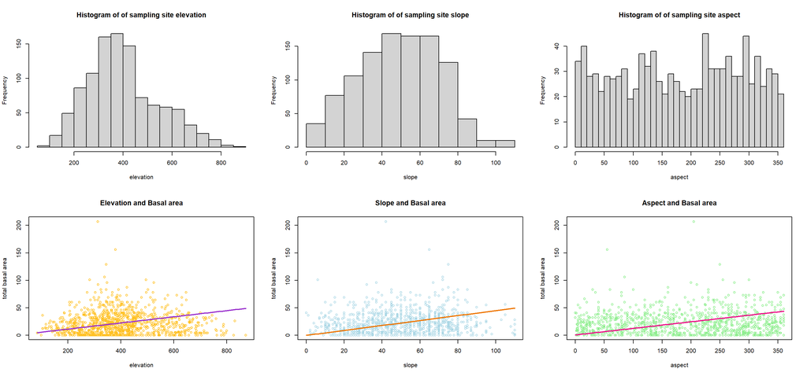

## Q8

The relationship between the elevation and the total basal area of trees seems to be highest in low to mid level elevations. The highest total basal area values seem to be clustered around the same elevation points we saw most sampled, 300-400 m range. The relationship between elevation and total basal area is not linear, and a linear model would not be a good fit because at very low and high elevations the total basal area of the trees is much smaller, the fit should fit the slightly bell shaped distribution of this data.

The relationship between the slope and the total basal area of trees has an unclear association. The highest total basal area values seem to be more or less evenly distributed along all measured slopes, which indicated that linear model is definitely not the correct fit. Although, on the more extreme ends the slope measurements, i.e. most shallow and most steep slopes, there looks to be clusters of smaller total basal areas, but overall I do not think slope matters or is very important to determining the total basal area of a tree.